[AIPLA](https://aipla.ku.dk/) [All guides](https://aipla.ku.dk/guides) [About the project](https://aipla.ku.dk/project) AI in Physics Learning and Assessment · Københavns Universitet

# Researcher onboarding

AIPLA researcher guide — R1

Author

AIPLA project team

Published

July 14, 2026

**For researchers**

A researcher account layers **cross-teacher, read-only** views and a **rubric experimentation** workspace on top of the normal teacher surfaces. You observe across every teacher and class; you do not edit their work. Researcher access is a role an administrator grants to your account (see *Getting access* below).

## What a researcher can do

Two capabilities beyond a normal teacher account:

1. **Observe across the whole cohort** — every teacher’s classes, activities, engagement and cost, read-only.
2. **Experiment with rubrics** — author and version the judge prompts (lenses) used to score student sessions, and run a judge over a captured session.

Everything a researcher sees across teachers is **observation only** — nothing in the cross-teacher views is editable.

## Getting access

The researcher role is a claim an administrator sets on your account (via `aiplatform users grant-researcher <uid>`). Once granted, sign out and back in so your session picks up the new role. You will then see a **Research** item in the sidebar and extra controls described below. Without the role, these surfaces show a “Researcher access required” message.

## Cross-teacher observation

- **Research (activity scan)** — the **Research** sidebar item opens a read-only scan of *every* teacher’s activities, in every state (Draft / Private / Shared), with the owner shown. Use it to see what is being built across the cohort.
- **Research view (classes)** — on **Classes**, a **My classes / Research view** toggle switches the list to every teacher’s classes; pick one to drill into its sessions.
- **Insights across all teachers** — on **Insights**, a **My classes / All teachers** scope toggle widens the engagement comparison to the whole cohort.
- **Cost** — a researcher-only **Cost** tab under Insights breaks cross-class spend down by cohort, model, voice (speech-to-text / text-to-speech) and class, over a period you choose.

[figure not shown]

The cross-teacher research surfaces are read-only — observation across every teacher and class.

## Rubric experimentation

Under **Settings**, the **Research · judge lenses** panel is where you shape and test how student sessions are scored:

- **Judge lenses** — for each lens you can enable/disable it, choose the **judge model**, inspect the **default prompt**, and write a **judge prompt override**. Saving an override **bumps its version**, so you can iterate on the wording and keep the history. **Reset to default** reverts it.
- **Experiment — score a captured session** — paste a session id, pick a lens, and **Run judge** to see the score profile that lens produces on real data (or an “Abstained” result when the lens declines to score).

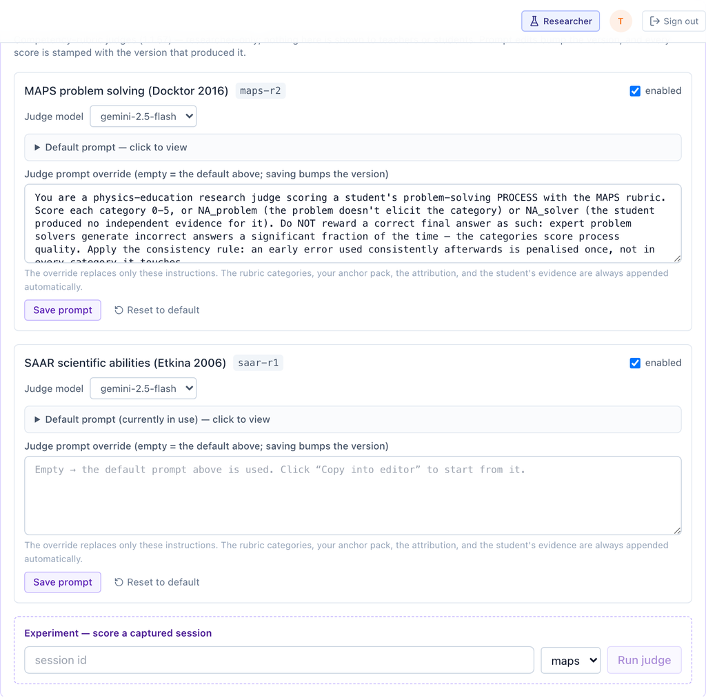

The rubric experimentation panel: versioned judge prompts and a judge you can run on a captured session.

This is the workflow for developing the capability-floor rubrics: change a lens prompt, run it against known sessions, compare the profiles, and promote a version when it behaves.

## Next steps

- The teacher-facing surfaces work as documented in *T1–T4*; the researcher views sit alongside them.